# Project 2 - Bank Marketing

### Import Data

```python
import pandas as pd
```

```python
data = pd.read_csv("bank-marketing.csv")
data.head(5)
```

|  | age | job | marital | education | default | housing | loan | contact | month | day_of_week | ... | campaign | pdays | previous | poutcome | emp.var.rate | cons.price.idx | cons.conf.idx | euribor3m | nr.employed | y |
| --- | --- | --- | --- | --- | --- | --- | --- | --- | --- | --- | --- | --- | --- | --- | --- | --- | --- | --- | --- | --- | --- |
| 0 | 56 | housemaid | married | basic.4y | no | no | no | telephone | may | mon | ... | 1 | 999 | 0 | nonexistent | 1.1 | 93.994 | -36.4 | 4.857 | 5191.0 | no |
| 1 | 57 | services | married | high.school | unknown | no | no | telephone | may | mon | ... | 1 | 999 | 0 | nonexistent | 1.1 | 93.994 | -36.4 | 4.857 | 5191.0 | no |
| 2 | 37 | services | married | high.school | no | yes | no | telephone | may | mon | ... | 1 | 999 | 0 | nonexistent | 1.1 | 93.994 | -36.4 | 4.857 | 5191.0 | no |
| 3 | 40 | admin. | married | basic.6y | no | no | no | telephone | may | mon | ... | 1 | 999 | 0 | nonexistent | 1.1 | 93.994 | -36.4 | 4.857 | 5191.0 | no |
| 4 | 56 | services | married | high.school | no | no | yes | telephone | may | mon | ... | 1 | 999 | 0 | nonexistent | 1.1 | 93.994 | -36.4 | 4.857 | 5191.0 | no |

5 rows × 21 columns

```python
# print(data.columns.tolist())
```

```python
data.info()
```

```
<class 'pandas.core.frame.DataFrame'>
RangeIndex: 41188 entries, 0 to 41187
Data columns (total 21 columns):
 #   Column          Non-Null Count  Dtype
---  ------          --------------  -----
 0   age             41188 non-null  int64
 1   job             41188 non-null  object
 2   marital         41188 non-null  object
 3   education       41188 non-null  object
 4   default         41188 non-null  object
 5   housing         41188 non-null  object
 6   loan            41188 non-null  object
 7   contact         41188 non-null  object
 8   month           41188 non-null  object
 9   day_of_week     41188 non-null  object
 10  duration        41188 non-null  int64
 11  campaign        41188 non-null  int64
 12  pdays           41188 non-null  int64
 13  previous        41188 non-null  int64
 14  poutcome        41188 non-null  object
 15  emp.var.rate    41188 non-null  float64
 16  cons.price.idx  41188 non-null  float64
 17  cons.conf.idx   41188 non-null  float64
 18  euribor3m       41188 non-null  float64
 19  nr.employed     41188 non-null  float64
 20  y               41188 non-null  object
dtypes: float64(5), int64(5), object(11)
memory usage: 6.6+ MB
```

### Select Attributes

```python
data.shape
```

```
(41188, 21)
```

```python
data.dtypes
```

```
age                 int64
job                object
marital            object
education          object
default            object
housing            object
loan               object
contact            object
month              object
day_of_week        object
duration            int64
campaign            int64
pdays               int64
previous            int64
poutcome           object
emp.var.rate      float64
cons.price.idx    float64
cons.conf.idx     float64
euribor3m         float64
nr.employed       float64
y                  object
dtype: object
```

**Observation**

- The dataset has total 21 columns and 41188 rows.
- It has 11 object attributes and 10 numerical attributes.
- The target column is y which represents "subscribe decision by customers"

### Correlation Analysis

```python
correl = data.corr(method='pearson')
correl
```

|  | age | duration | campaign | pdays | previous | emp.var.rate | cons.price.idx | cons.conf.idx | euribor3m | nr.employed |
| --- | --- | --- | --- | --- | --- | --- | --- | --- | --- | --- |
| age | 1.000000 | -0.000866 | 0.004594 | -0.034369 | 0.024365 | -0.000371 | 0.000857 | 0.129372 | 0.010767 | -0.017725 |
| duration | -0.000866 | 1.000000 | -0.071699 | -0.047577 | 0.020640 | -0.027968 | 0.005312 | -0.008173 | -0.032897 | -0.044703 |
| campaign | 0.004594 | -0.071699 | 1.000000 | 0.052584 | -0.079141 | 0.150754 | 0.127836 | -0.013733 | 0.135133 | 0.144095 |
| pdays | -0.034369 | -0.047577 | 0.052584 | 1.000000 | -0.587514 | 0.271004 | 0.078889 | -0.091342 | 0.296899 | 0.372605 |
| previous | 0.024365 | 0.020640 | -0.079141 | -0.587514 | 1.000000 | -0.420489 | -0.203130 | -0.050936 | -0.454494 | -0.501333 |
| emp.var.rate | -0.000371 | -0.027968 | 0.150754 | 0.271004 | -0.420489 | 1.000000 | 0.775334 | 0.196041 | 0.972245 | 0.906970 |
| cons.price.idx | 0.000857 | 0.005312 | 0.127836 | 0.078889 | -0.203130 | 0.775334 | 1.000000 | 0.058986 | 0.688230 | 0.522034 |
| cons.conf.idx | 0.129372 | -0.008173 | -0.013733 | -0.091342 | -0.050936 | 0.196041 | 0.058986 | 1.000000 | 0.277686 | 0.100513 |
| euribor3m | 0.010767 | -0.032897 | 0.135133 | 0.296899 | -0.454494 | 0.972245 | 0.688230 | 0.277686 | 1.000000 | 0.945154 |
| nr.employed | -0.017725 | -0.044703 | 0.144095 | 0.372605 | -0.501333 | 0.906970 | 0.522034 | 0.100513 | 0.945154 | 1.000000 |

### Feature Selection

```python
import matplotlib.pyplot as plt
```

#### Univariate Plots

##### Histogram

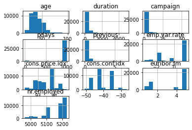

```python
data.hist()
plt.show()
```

##### Density Plot

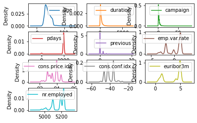

```python
data.plot(kind='density', subplots=True, layout=(4,3), sharex=False)
plt.show()
```

##### Box Plot

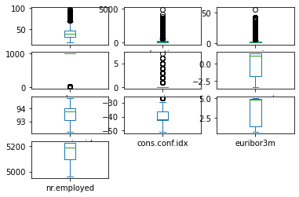

```python
data.plot(kind='box', subplots=True, layout=(4,3), sharex=False,sharey=False)
plt.show()
```

**Observation**

- From the histogram and density plot, we can see that "age" column has the bell shape.
- There are many outliers in data of "age", "duration", "campaign", and "previous" features.
- The data range of every columns seem reasonable.

**Feature Selection based on Univariate Plots**

- We will choose "age" column for numerical feature selection.

#### Multivariate Plots

##### Correlation Matrix Plot

```python
import numpy
```

**>>> Note**

- Because Correlation Matrix Plot requires only numeric attributes, we need to create a extracted numeric dataset.

```python
numerics = ['int16', 'int32', 'int64', 'float16', 'float32', 'float64']
df = data.select_dtypes(include=numerics)
headers = list(df.columns.values)
headers
```

```
['age',
 'duration',
 'campaign',
 'pdays',
 'previous',
 'emp.var.rate',
 'cons.price.idx',
 'cons.conf.idx',
 'euribor3m',
 'nr.employed']
```

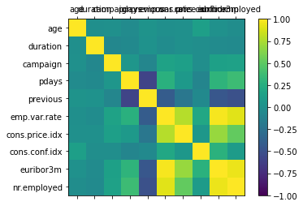

```python
correlations = data.corr()
fig = plt.figure()
ax = fig.add_subplot(111)
cax = ax.matshow(correlations, vmin=-1, vmax=1)
fig.colorbar(cax)
ticks = numpy.arange(0,10,1)
ax.set_xticks(ticks)
ax.set_yticks(ticks)
ax.set_xticklabels(headers)
ax.set_yticklabels(headers)
plt.show()
```

**Observation** There are some strong positive correlation between features:

- emp.var.rate and euribor3m
- emp.var.rate and cons.price.idx
- emp.var.rate and nr.employed
- euribor3m and cons.price.idx
- euribor3m and nr.employed

##### Scatter Plot

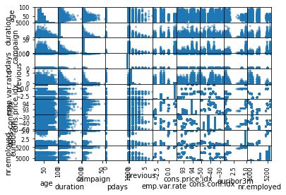

```python
pd.plotting.scatter_matrix(data)
plt.show()
```

**Observation**

#### Decision for Feature Selection

- Based on Univariate Plots, we choose "age" for numeric feature.
- Based on Multivariate Plots, we can also choose "previous" for numeric feature.
- Besides, we also want to discover "duration" feature which represents the last contact duration, in seconds (numeric), because the dataset author mentioned that this attribute highly affects the output target (e.g., if duration=0 then y='no').

### Data Visualization

#### Bar Chart

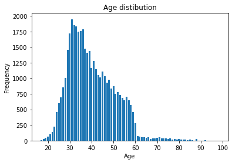

```python
# Visualizing data for age using bar chart
import matplotlib.pyplot as plt

plt.title('Age distibution')
plt.xlabel('Age')
plt.ylabel('Frequency')
plt.bar(data['age'].value_counts().index,data['age'].value_counts().values)
plt.show()
```

**Explanation**

- From the bar chart of "age" distribution, most of surveyed customers have age range from 25 to 60 years old. We can see that most of them are still in the labor age.
- The mode is in the age range of 30 to 35 years old. This is the age that when people often have some years of working experiences and may leverage their career to senior or manager position.
- This bar chart is also a positively skewed (or right-skewed) distribution where most values are sitting around the left tail while the right tail of is longer with some outliers.

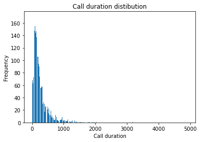

```python
# Visualizing data for Call duration using bar chart
plt.title('Call duration distibution')
plt.xlabel('Call duration')
plt.ylabel('Frequency')
plt.bar(data['duration'].value_counts().index,data['duration'].value_counts().values)
plt.show()
```

**Explanation**

- From the bar chart of "call duration" feature, we can see that most data ranges from the value of 0 to 600.
- The mode is around the value of 100.
- This bar chart also represents for a positively skewed (or right-skewed) distribution where most values are sitting around the left tail while the right tail of is longer with some outliers over the value of 600.

#### Pie Chart

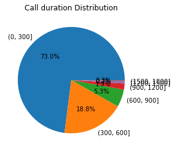

```
(0, 300]        29980
(300, 600]       7740
(600, 900]       2183
(900, 1200]       768
(1200, 1500]      307
(1500, 1800]      105
Name: duration_bin, dtype: int64
```

```python
# Visualizing data for Call duration using pie chart
# plt.pie(data['duration'].value_counts(), labels=data['duration'].value_counts().index.sort_values(), autopct="%1.1f%%")
# plt.title('Call duration Distribution')
# plt.show()
# print(data['duration'].value_counts())

# Define intervals
intervals = range(0, 2001, 300)

data['duration_bin'] = pd.cut(data['duration'], intervals)
duration_counts = data['duration_bin'].value_counts()

# Plot pie chart
plt.pie(duration_counts, labels=duration_counts.index, autopct="%1.1f%%")
plt.title('Call duration Distribution')
plt.show()

# data counts within intervals
print(duration_counts)
```

**Explanation**

- This pie chart of "call duration" together with the bar chart above helps us to understand more clearly about this feature.
- From the pie chart, we can see that about 70% having the call duration in range from 0 to 300.
- And, nearly 20% of the call duration is in range from 300 to 600.
- About 10% of call duration has the outlier values above 600.
- Hence, this pie chart of "call duration" matches with its bar chart.

#### Box Plot

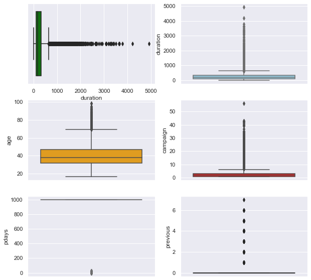

```python
# age               0.784697
# duration          3.263141
# campaign          4.762507
# pdays            -4.922190
# previous          3.832042
# emp.var.rate     -0.724096
# cons.price.idx   -0.230888
# cons.conf.idx     0.303180
# euribor3m        -0.709188
# nr.employed      -1.044262

import seaborn as sns
sns.set(style="darkgrid")
fig, axs1 = plt.subplots(3, 2, figsize=(10, 10))
sns.boxplot(data=data, x="duration", ax=axs1[0, 0], color='green')
sns.boxplot(data=data, y="duration",  ax=axs1[0, 1], color='skyblue')
sns.boxplot(data=data, y="age", ax=axs1[1, 0], color='orange');
sns.boxplot(data=data, y="campaign", ax=axs1[1, 1], color='red');
sns.boxplot(data=data, y="pdays", ax=axs1[2, 0], color='violet');
sns.boxplot(data=data, y="previous", ax=axs1[2, 1], color='purple');
```

#### Heat Map

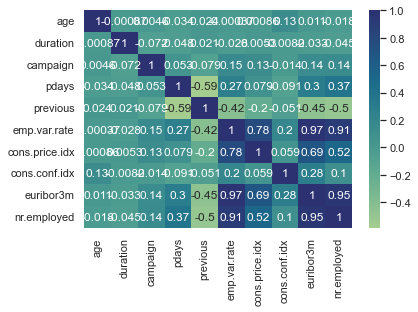

```python
numeric_data = data.select_dtypes(include='number')
sns.heatmap(numeric_data.corr(), annot=True, cmap='crest')
```